# Crop Condition Monitoring and Forecasting for the ICPAC Region

From planting dekad to risk maps to yield estimates — as-built methodology, 40 products across 10 countries and 5 crops

26 September 2026

# 1. Scope and what this report is

This is an **as-built** description of the operational pipeline: what it computes, from which data, with which parameters, and how well each output has been shown to work. It covers the whole chain — **planting dekad → risk maps → yield estimates** — for **40 products**: 18 sorghum, 15 maize, 4 wheat, 2 millet, 1 teff, across **10 countries** (Burundi, Eritrea, Ethiopia, Kenya, Rwanda, Somalia, South Sudan, Sudan, Tanzania, Uganda).

Where the as-built method departs from the Inception Report, §8 states the departure, the reason, and the peer-reviewed basis for it.

**Every table here is computed from the shipped products at build time, and every figure is regenerated from those same products by `report/make_figures.py`.** No figure is carried over from an earlier run. Rebuild with:

```bash
python report/make_figures.py && python report/build_report.py
```

## 1.1 Headline state of the pipeline

| products built | **40** (18 sorghum, 15 maize, 4 wheat, 2 millet, 1 teff) |
| --- | --- |
| countries | 10 |
| yield ceilings fitted against official statistics | **22** of 40 |
| …of which rank admin units **usably** (r ≥ 0.4) | **5** |
| …of which rank admin units **backwards** (r < 0) | **8** |
| products where a rainfed balance misreads irrigation | **9** (1 invalid, 6 materially biased, 2 locally biased) |
| tier-2 metrics (SPI-3, deficit, LVPD, FCCI) | complete for sorghum, wheat, teff, millet |

**The honest summary is that planting dekad is the strongest link in the chain, risk is sound where the crop is rainfed, and yield is the weakest — 8 of 22 fitted ceilings order admin units backwards.** §7 and §9 give the evidence and what to do about it.

# 2. Countries, crops and coverage

The **ICPAC crop-type mask decides which crops run in which country**. A season-calendar row for a country whose mask carries no band for that crop cannot be computed, and is dropped at planning time rather than failing mid-build (`crop_coverage.py`).

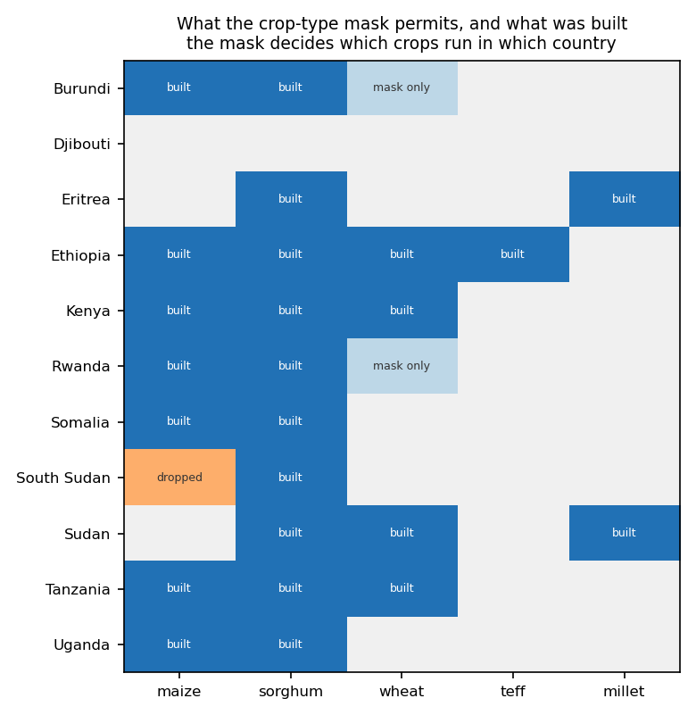

Figure 1. What the crop-type mask permits and what was built. ‘mask only’ = buildable, no calendar row yet; ‘dropped’ = a decision, recorded with its evidence.

# 3. Data inputs

| input | product | role | reference |
| --- | --- | --- | --- |
| Rainfall | CHIRPS v2.0, daily/dekadal, 0.05° | onset rule, water balance supply term, SPI-3 | Funk et al. 2015 |
| Temperature | ERA5-Land hourly → dekadal Tmin/Tmax | Hargreaves ET₀, flowering heat | Muñoz-Sabater et al. 2021 |
| Reference ET | Hargreaves–Samani from ERA5-Land | crop water requirement `Kc·ET₀` | Hargreaves & Samani 1985 |
| Soil water | SoilGrids 2.0 texture → Saxton–Rawls θ₃₃/θ₁₅₀₀ | WHC over the crop’s rooting depth | Poggio et al. 2021; Saxton & Rawls 2006 |
| Optical | Sentinel-2 L2A, NDRE | green-up onset cue | Eisfelder et al. 2024 |
| Radar | Sentinel-1 GRD, VH/VV → RVI | cloud-proof onset cue | (SAR SOS literature, §11) |
| Canopy | MODIS MCD15A3H FPAR | onset cue, zFPAR anomaly | Myneni et al. |
| Biomass | MODIS MOD17A2HGF GPP → DMP | independent yield-ranking covariate | Running et al. 2004; Monteith 1972 |
| Crop area | ICPAC crop-type mask, 100 m (MapSPAM prior) | the stratum every product is computed over | IFPRI MapSPAM; §4 |
| Irrigation | MapSPAM 2020 `_I`/`_A` physical area | exposure grading (§7.3) | IFPRI MapSPAM |
| Boundaries | GADM 4.1 (GAUL where absent) | zonal reduction | GADM |
| Yield statistics | HarvestStat Africa v1.2 | Ym calibration and validation | Lee et al. 2025 |

# 4. The crop-type mask — the stratum everything is computed over

Every product is computed **inside a crop-specific mask**, not over all cropland. The ICPAC crop-type mask is a dasymetric allocation of MapSPAM crop shares onto a four-lineage, sixteen-source-year stable cropland vote, reweighted by agro-climatic suitability and satellite crop evidence, and calibrated to sub-national statistics where they exist. It reproduces reported crop area to **92–99 %** across the eight maize countries.

This **is** the Inception Report’s Tier 1, built stronger than the report assumed (§8.1).

`ctm_mask.crop_mask()` **raises rather than falling back**. That matters: the generic `run.crop_mask_image` would return the WorldCereal *temporary-crops* extent — all cropland — for any non-maize crop. No shipped product ever ran that way, because sorghum, wheat, teff and millet used the crop-type mask from the start; the raise is what keeps it that way.

# 5. Module 1 — Planting dekad (onset)

## 5.1 Three onset routes, chosen per product

1. **Green-up cue fusion** — Sentinel-2 NDRE + MODIS FPAR + Sentinel-1 RVI, for main seasons where cloud allows. Fusing an optical cue with SAR is what makes onset retrievable under cloud (Eisfelder et al. 2024; SAR-SOS literature).
2. **Rainfall-anchored onset** — the FEWS/GeoWRSI rule: 25 mm in a dekad followed by 20 mm in each of the next two, with a **5+7 dekad false-start gate** (Senay & Verdin 2003; Sivakumar 1988; Stern et al. 1982). Used for short and second seasons, and for cloudy equatorial highlands.
3. **Fixed scheme date** — for irrigated products, where planting is scheduled rather than rain-driven and neither detector can fire (§7.3).

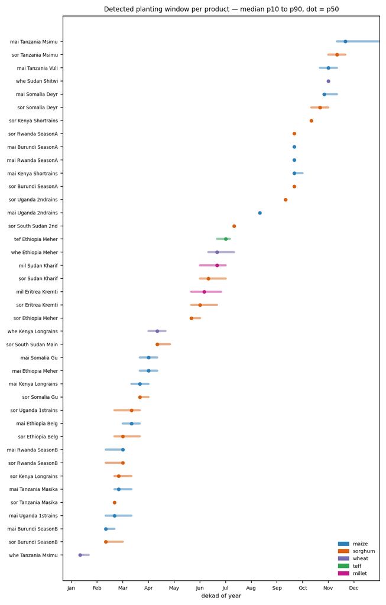

Figure 2. Detected planting window per product — median p10 to p90 across admin units, dot = p50. The spread is the product’s own detected variability, not the calendar window.

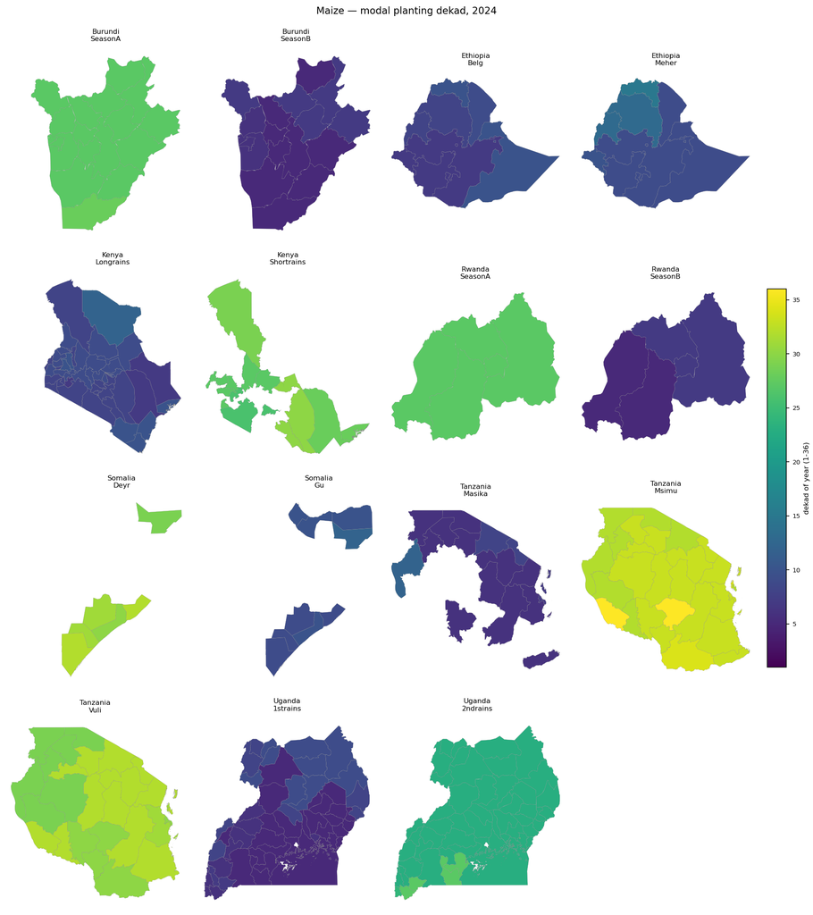

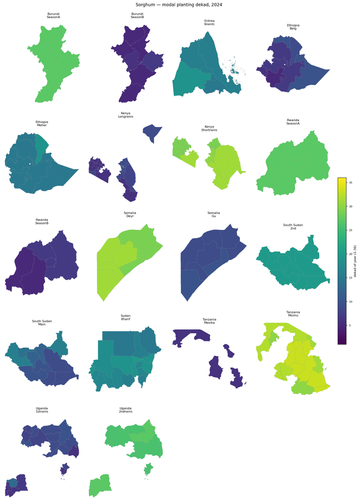

Figure 4. Sorghum — modal planting dekad, 2024, 18 products across 10 countries.

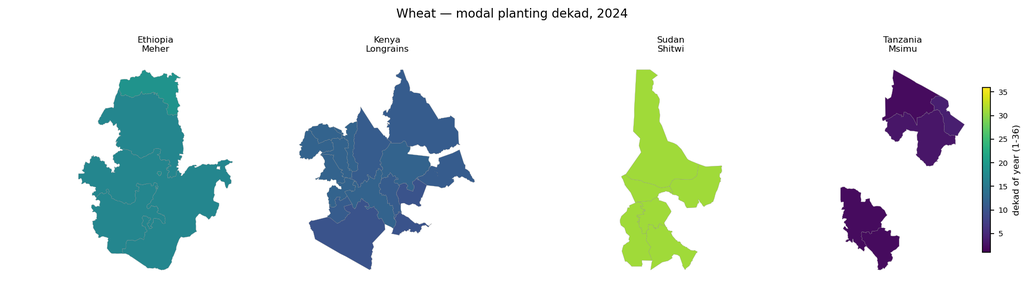

Figure 5. Wheat — modal planting dekad, 2024.

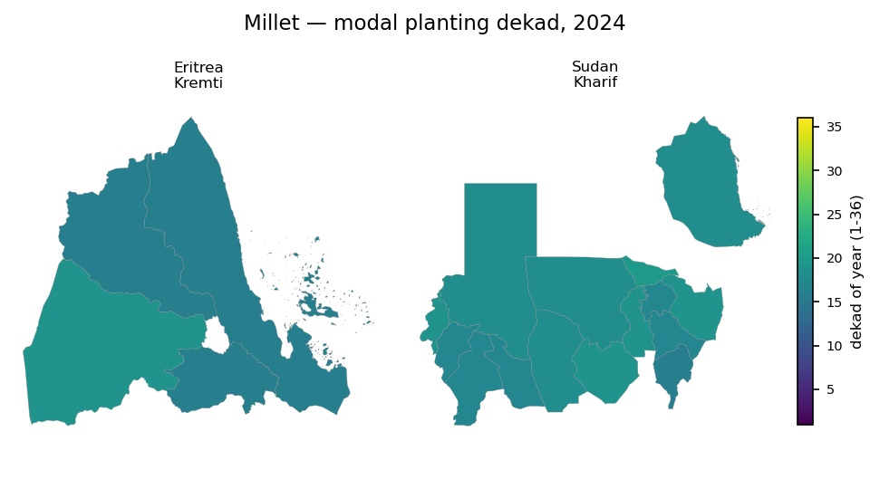

Figure 6. Millet — modal planting dekad, 2024.

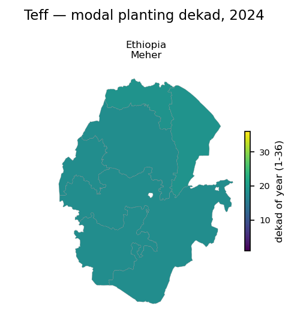

Figure 7. Teff — modal planting dekad, Ethiopia Meher 2024.

## 5.2 Validation — the strongest link in the chain

Against **4.8 million Kenyan farmer planting records** (MAM 2024): **92.9 % of admin units within ±2 dekads**, and **100 % within the GIEWS calendar window**. Ethiopia Meher: **100 % in window**.

This is the only part of the chain with independent ground truth at scale, and it is the part that performs best. Outside Kenya and Ethiopia there is no comparable reference, so planting dekad elsewhere is validated only against calendar plausibility.

# 6. Module 2 — Risk monitoring

## 6.1 The water balance

A single-layer FAO-56 dekadal bucket (Allen et al. 1998), stepped over each pixel’s own cycle:

*W**R*<sub>*t*</sub> = *K*<sub>*c*</sub>(*d*) ⋅ *E**T*<sub>0, *t*</sub>

*W*<sub>*b*, *t*</sub> = *S**W*<sub>*t* − 1</sub> + *P*<sub>*t*</sub>

*A**E**T*<sub>*t*</sub> = min (*W*<sub>*b*, *t*</sub>, *W**R*<sub>*t*</sub>)

*S**W*<sub>*t*</sub> = min (max (*W*<sub>*b*, *t*</sub> − *A**E**T*<sub>*t*</sub>, 0), *W**H**C*)

$$WRSI = 100\cdot\frac{\sum_{t}
AET_t}{\sum_{t} WR_t}$$

where *t* indexes dekads over the crop cycle, *d* is dekads since planting, *K*<sub>*c*</sub>(*d*) is the FAO-56 crop coefficient at that stage, *E**T*<sub>0, *t*</sub> is Hargreaves reference evapotranspiration, *P*<sub>*t*</sub> is CHIRPS rainfall, and *W**H**C* is water-holding capacity over the crop’s own rooting depth. The supply term *W*<sub>*b*, *t*</sub> = *S**W*<sub>*t* − 1</sub> + *P*<sub>*t*</sub> carries **no irrigation term** - see section 7.3.

with a dry start (`init_soil_water_frac = 0.0`), the WRSI convention (Verdin & Klaver 2002; Senay & Verdin 2003).

## 6.2 Stress components

$$S_{water} =
\operatorname{clamp}\!\left(\sum_{s\,\in\,\{veg,\,flo,\,grf\}}
K_{y,s}\left(1-\frac{AET_s}{WR_s}\right),\;0,\;1\right)$$

*S*<sub>*h**e**a**t*</sub> = clamp (*k*<sub>*H*</sub>∑<sub>*t* ∈ *f**l**o*</sub>max (0, *T*<sub>*m**a**x*, *t*</sub> − *T*<sub>*c**a**p*</sub>), 0, 1)

*S*<sub>*v**e**g*</sub> = *w*<sub>*v*</sub>(1 − VCI), *w*<sub>*v*</sub> = 0.4

*K*<sub>*y*, *s*</sub> is the FAO-33 stage yield-response factor, *k*<sub>*H*</sub> the heat coefficient per heat-degree-dekad, *T*<sub>*c**a**p*</sub> the crop’s flowering heat threshold, and *w*<sub>*v*</sub> the vegetation down-weight - *S*<sub>*v**e**g*</sub> confirms the balance rather than driving it.

Ky is the FAO-33 stage yield-response factor (Doorenbos & Kassam 1979) and is **the most consequential parameter set in the pipeline** — maize’s flowering Ky of 1.50 against sorghum’s 0.55 means a flowering deficit costs maize roughly three times what it costs sorghum.

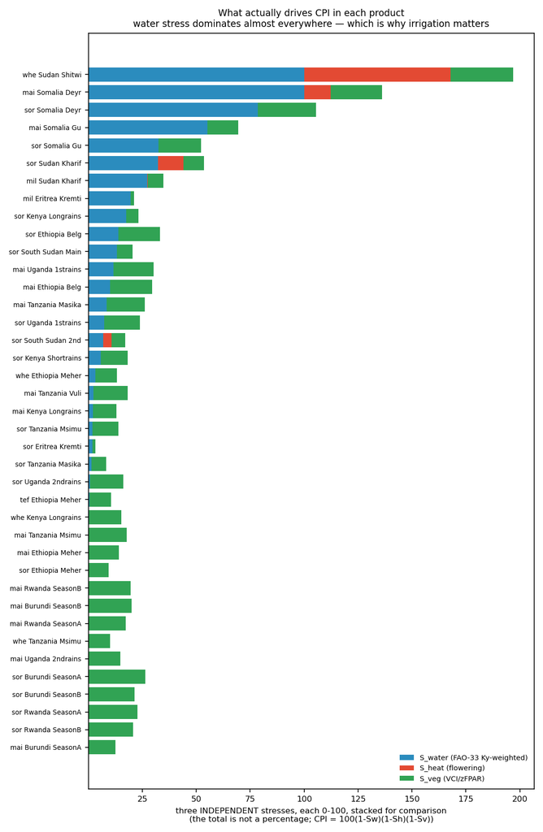

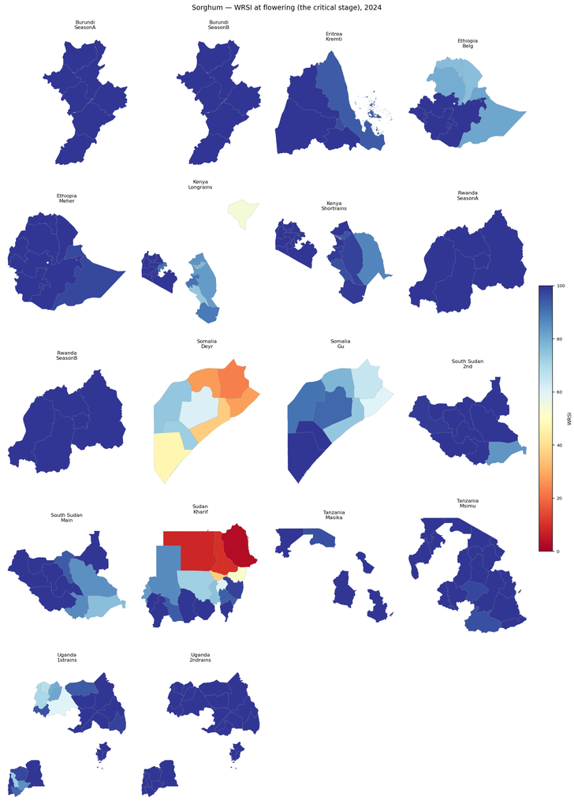

Figure 9. Sorghum — WRSI at flowering, the critical stage.

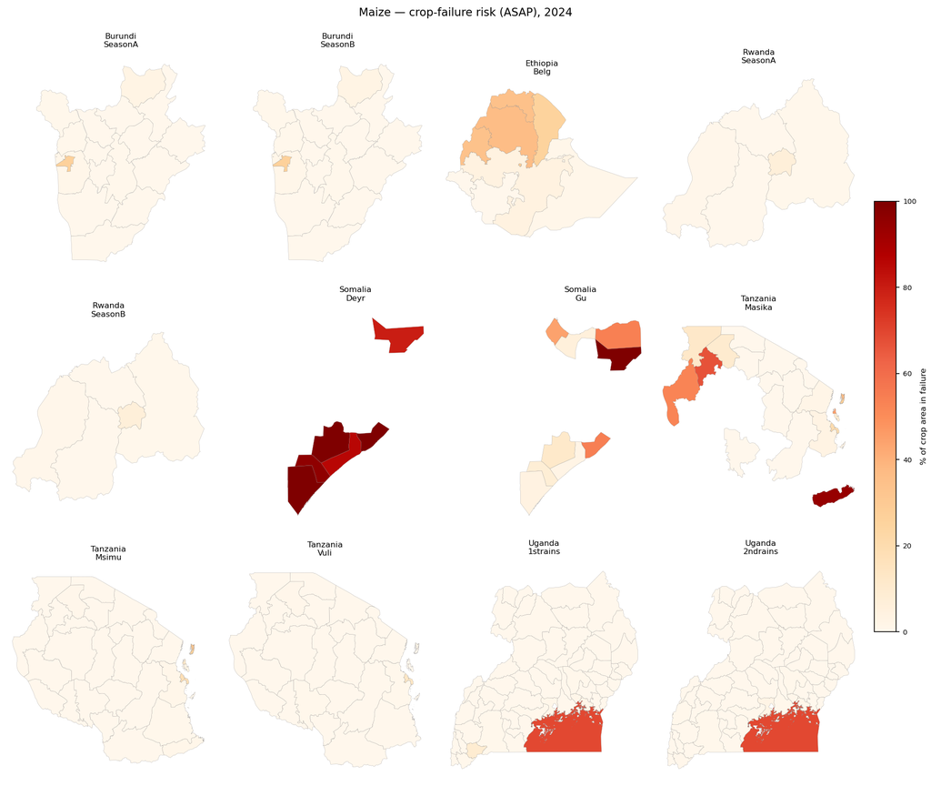

Figure 10. Maize — crop-failure risk, ASAP convention: % of crop area with stage WRSI < 50 (Rembold et al. 2019).

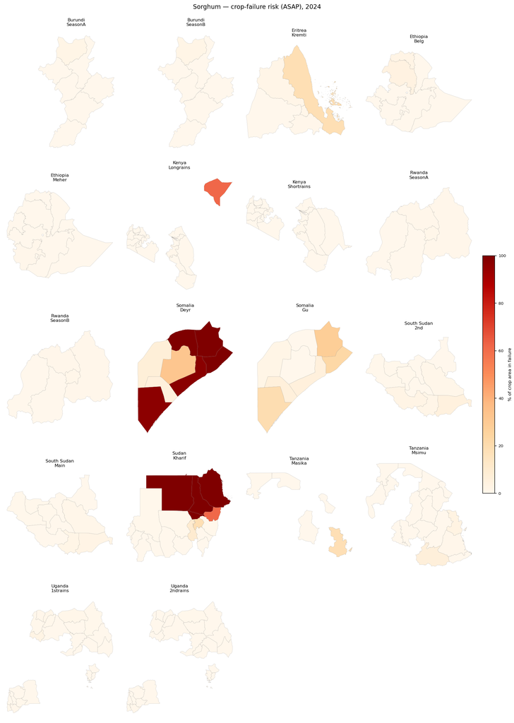

Figure 11. Sorghum — crop-failure risk, 2024.

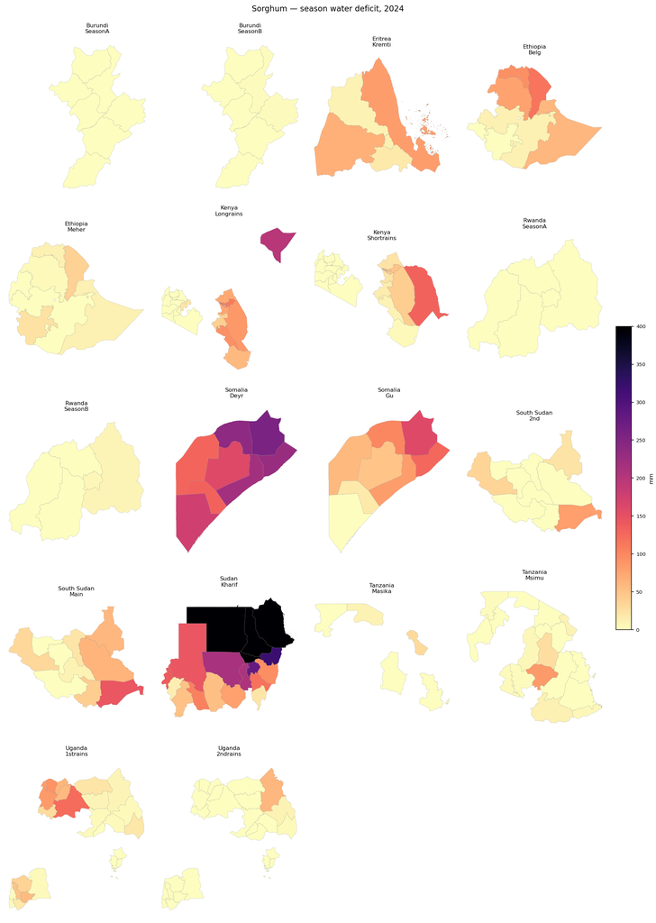

Figure 12. Sorghum — cumulative season water deficit (mm). On an irrigated product this quantity is the irrigation requirement, not crop stress (§7.3).

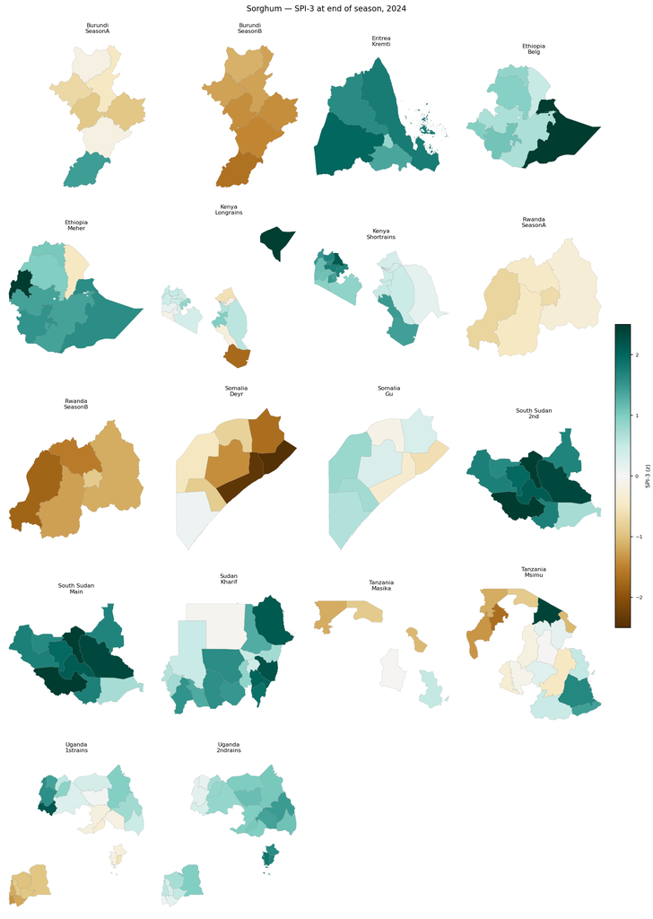

Figure 13. Sorghum — SPI-3 at end of season, the meteorological drought context for the balance.

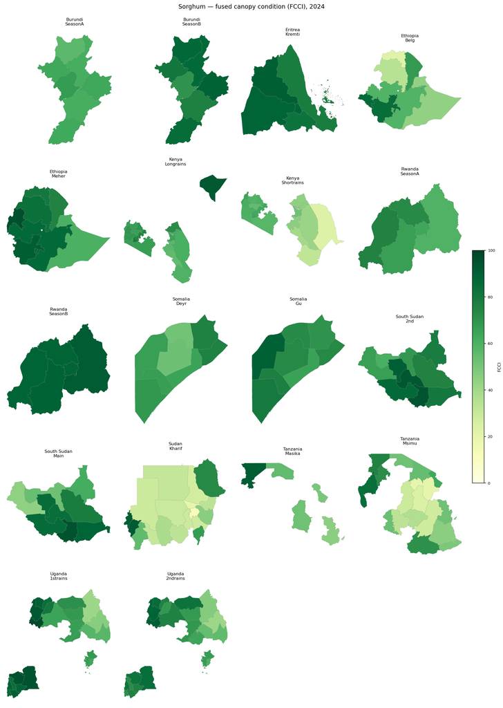

Figure 14. Sorghum — fused canopy condition (FCCI) from Sentinel-2, Sentinel-1 and FPAR: an observation-side check on a model-side product.

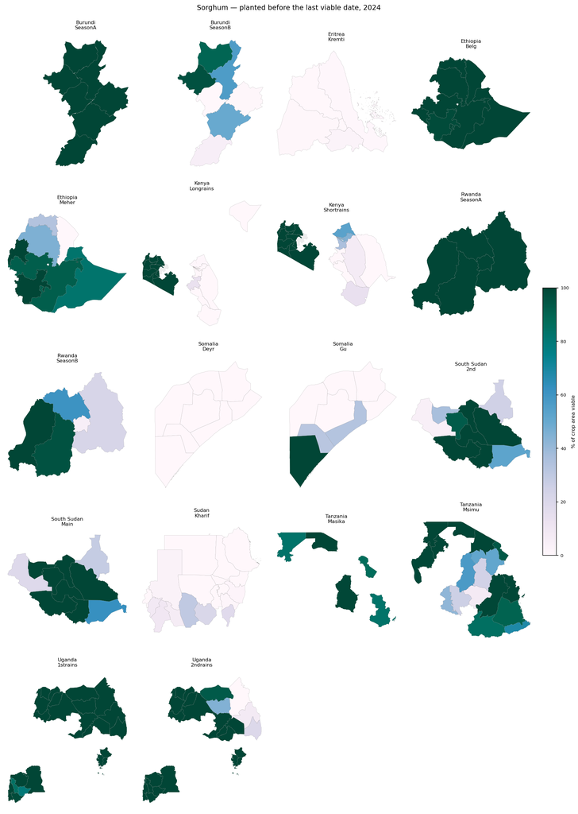

Figure 15. Sorghum — share of crop area planted before the climatological last viable planting date (LVPD).

# 7. Module 3 — Crop Performance Index and yield

## 7.1 The model

*C**P**I* = 100(1 − *S*<sub>*w**a**t**e**r*</sub>)(1 − *S*<sub>*h**e**a**t*</sub>)(1 − *S*<sub>*v**e**g*</sub>)

$$Y_a = \frac{CPI}{100}\cdot
Y_m$$

The combination is **multiplicative**, following FAO-33: a crop already lost to water deficit cannot be further reduced proportionally by heat. *Y*<sub>*m*</sub> is the attainable ceiling, fitted by least squares through the origin over HarvestStat units *i* with reported yield *y*<sub>*i*</sub>, weighted by crop area *w*<sub>*i*</sub>:

$$\hat{Y}_m = \frac{\sum_i w_i\, y_i\,
c_i}{\sum_i w_i\, c_i^{2}}, \qquad c_i = \frac{CPI_i}{100}$$

Ym is fitted by least squares through the origin of reported yield on CPI, with admin units weighted by crop area, against HarvestStat Africa v1.2 (Lee et al. 2025), 70/30 split repeated 200 times. The ceiling is the *attainable* yield in the yield-gap sense (van Ittersum et al. 2013; Lobell et al. 2009).

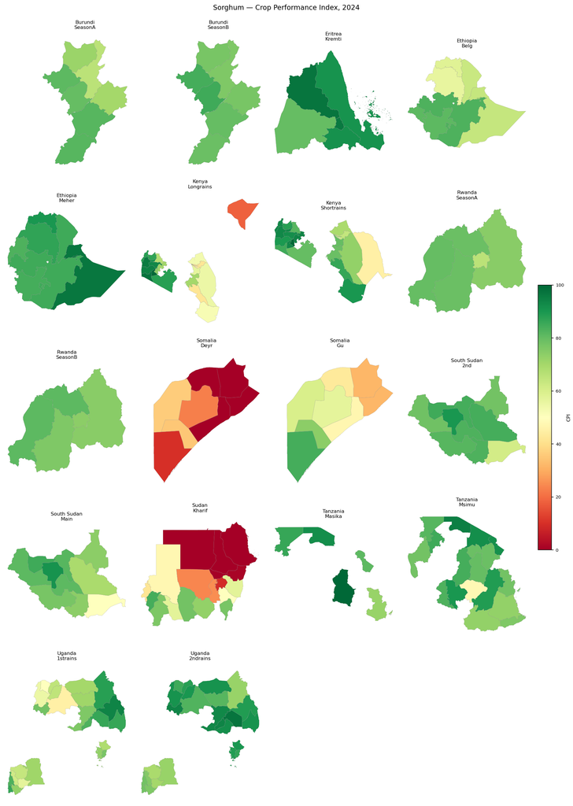

Figure 16. Sorghum — Crop Performance Index, 2024.

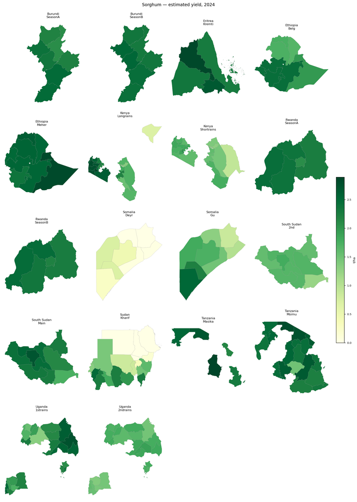

Figure 17. Sorghum — estimated yield (t/ha), 2024.

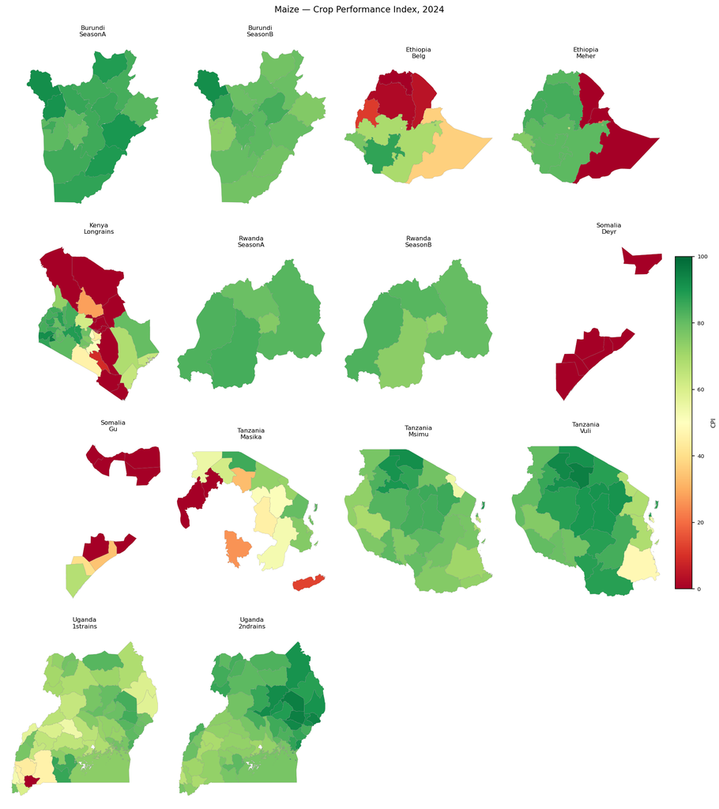

Figure 18. Maize — Crop Performance Index, 2024.

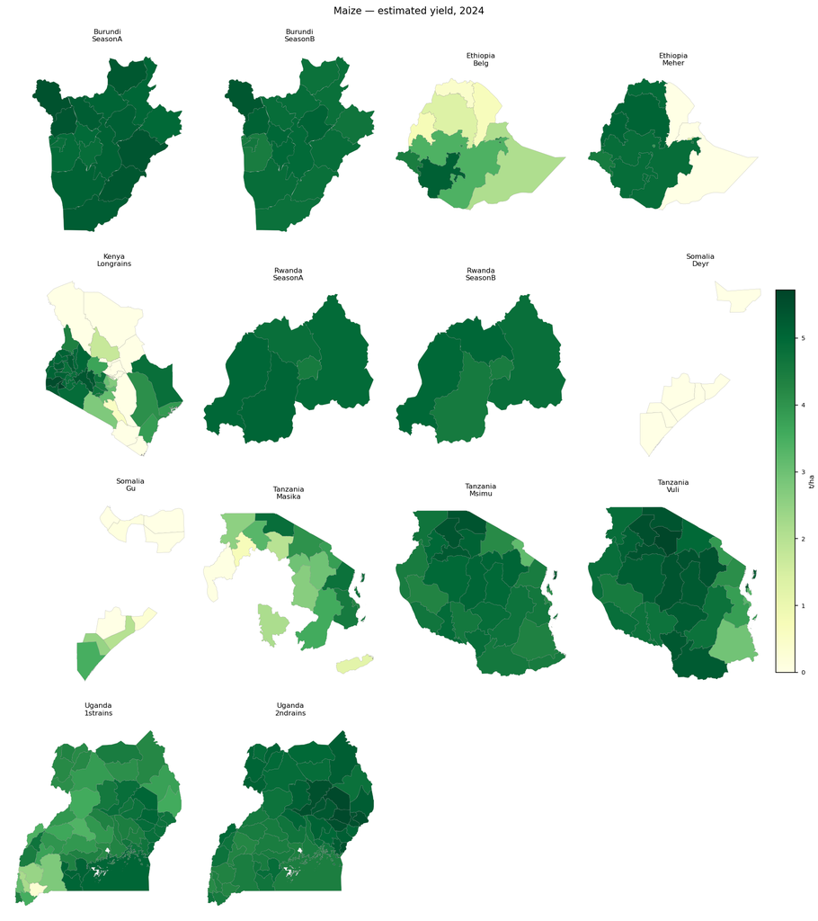

Figure 19. Maize — estimated yield (t/ha), 2024.

## 7.2 Yield is the weakest link, and here is the evidence

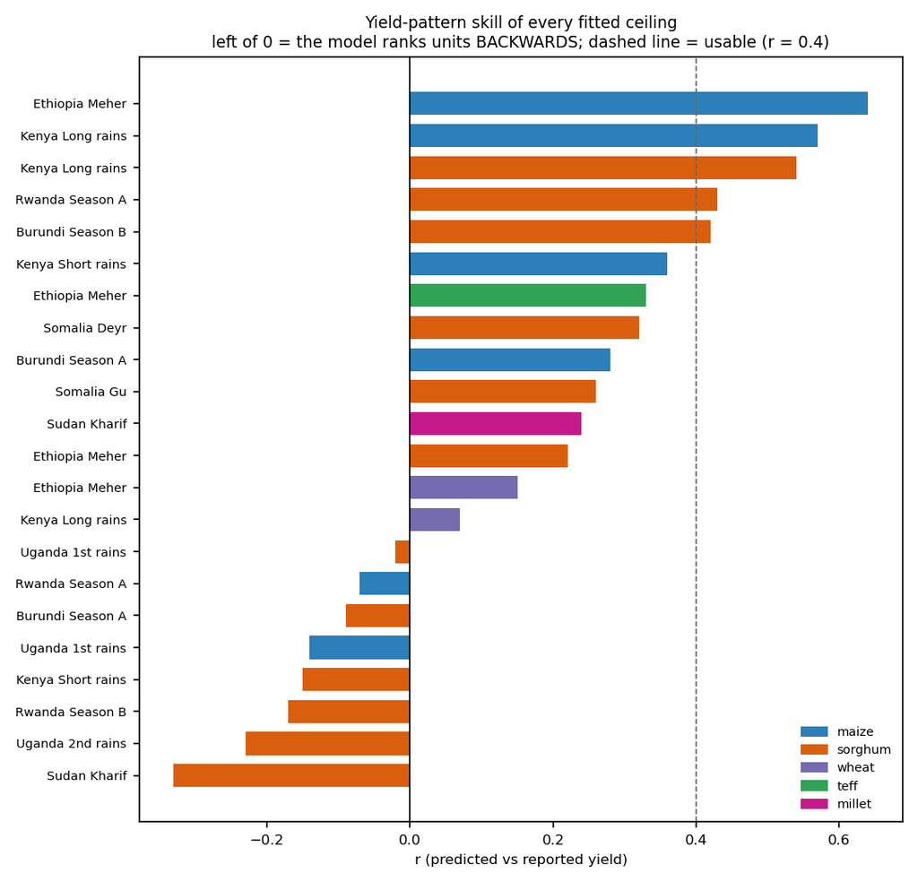

Figure 20. Yield-pattern skill of every fitted ceiling. Bars left of zero are products where the model orders admin units BACKWARDS against reported yield.

Of **22 fitted ceilings**: **5 rank usably** (r ≥ 0.4), **8 rank backwards** (r < 0).

A ceiling with r < 0 sets a plausible national average and then puts the wrong districts at the bottom. In an early-warning product that is worse than no ranking, because it carries the authority of a number. **These products should be read as levels, not as rankings**, until the cause is fixed.

| crop | country | season | ym | n | r |
| --- | --- | --- | --- | --- | --- |
| sorghum | Sudan | Kharif | 0.83 | 18 | -0.33 |
| sorghum | Uganda | 2nd rains | 1.13 | 50 | -0.23 |
| sorghum | Rwanda | Season B | 1.37 | 30 | -0.17 |
| sorghum | Kenya | Short rains | 1.09 | 24 | -0.15 |
| maize | Uganda | 1st rains | 2.34 | 74 | -0.14 |
| sorghum | Burundi | Season A | 0.55 | 7 | -0.09 |
| maize | Rwanda | Season A | 2.61 | 30 | -0.07 |
| sorghum | Uganda | 1st rains | 1.30 | 47 | -0.02 |
| wheat | Kenya | Long rains | 3.11 | 16 | 0.07 |
| wheat | Ethiopia | Meher | 2.69 | 52 | 0.15 |

## 7.3 Irrigation — the largest known systematic error

The balance is **rainfed by construction**: `Wb = SW + P` credits soil water and rainfall and nothing else. Where a crop is irrigated, the scheme meets a shortfall the model never sees, so WRSI and `S_water` measure the **irrigation requirement** while being reported as crop stress, and CPI and yield come out low.

Exposure is graded per (country, crop) from MapSPAM 2020’s irrigated/rainfed technology split: **1 invalid as a rainfed product, 6 materially biased, 2 locally biased, 31 unaffected.**

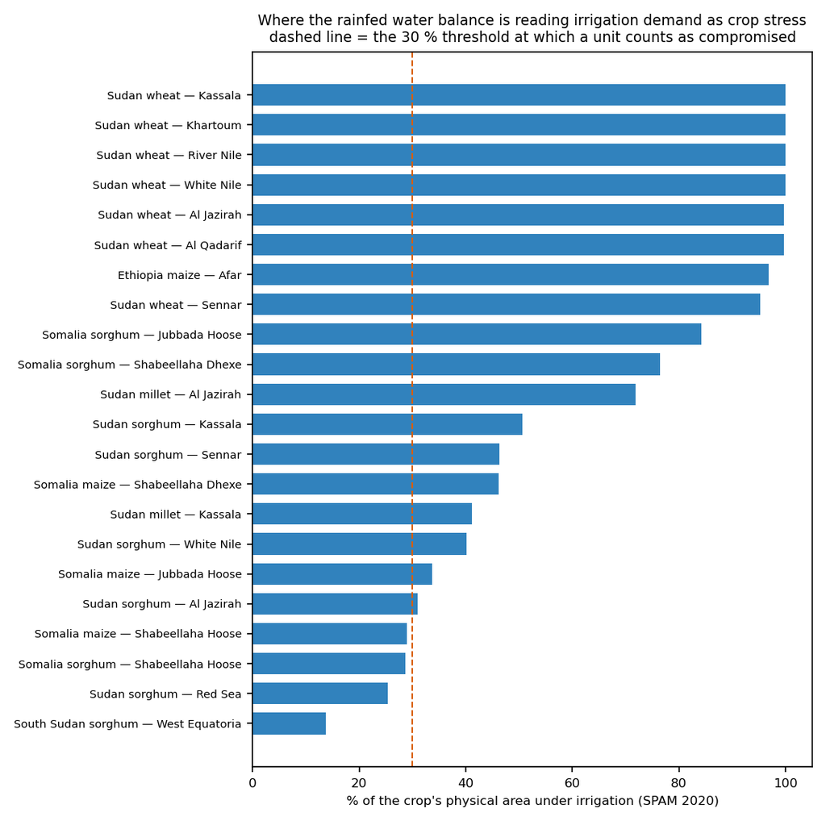

Figure 21. Admin units where the rainfed balance is reading irrigation demand as crop stress.

**Exposure is not proof of corruption.** Sudan sorghum has the most irrigated area of any product (288,569 ha) yet ρ = −0.17 (p = 0.50), because the 3.3 Mha Al Qadarif bulk is rainfed. The grade flags a product for inspection; the correlation decides.

Every Earth Engine asset carries `irrigation_exposure`; the apps show a banner; Sudan wheat Shitwi is excluded from apps and Atlas, its asset retained because the deficit *is* the irrigation requirement. Full treatment: `crop_pipeline/docs/IRRIGATED_WATER_BALANCE.md`.

## 7.4 DMP as a rescue for the products where the balance fails

The test is **rank-only**, which removes DMP’s dominant uncertainty: Spearman ρ is invariant to monotonic transforms, so harvest index, above-ground fraction and grain moisture cannot affect it.

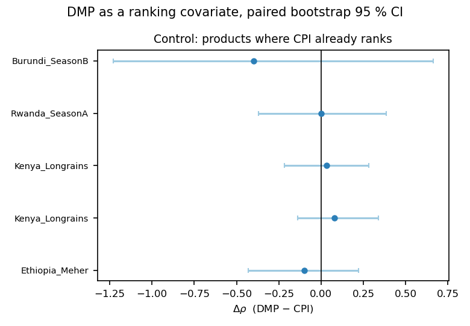

| set | DMP better | CPI better | indistinguishable | median Δρ |
| --- | --- | --- | --- | --- |
| CPI ranks **backwards** (n=8) | **3** | 0 | 5 | **+0.337** |
| CPI **already works** (n=5) | 0 | 0 | 5 | +0.001 |

DMP’s ρ is positive in 6 of 8 anti-correlated products; CPI’s is positive in **0 of 8**. On the control set the two are a dead heat. The supported claim is therefore the narrow one: **DMP adds nothing where the water balance already works, and recovers a usable ranking where it does not.**

### How it is delivered, and the two guards on it

DMP reaches users in two places, and both are built so the layer cannot be mistaken for something it is not.

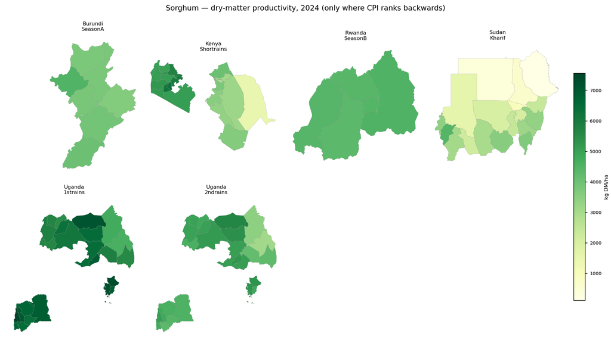

Figure 26. Sorghum dry-matter productivity on the six products that carry it. The blank countries are not missing data — DMP is computed only where CPI ranks admin units backwards, because it adds nothing where the water balance already works.

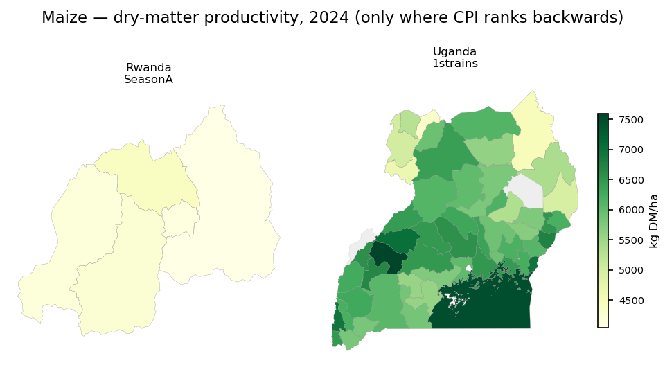

Figure 27. Maize dry-matter productivity, Uganda 1st rains and Rwanda Season A — the two maize products whose fitted ceiling is anti-correlated with reported yield.

## 7.5 Can DMP carry a level? Sixteen representative frames say no

Dry-matter productivity (DMP) is the rate at which a canopy accumulates dry biomass, kg DM/ha/day, integrated over the season. It is derived here from MODIS MOD17 gross primary productivity via carbon-use efficiency and carbon fraction, standing in for the Copernicus Global Land DMP product, which is not in the Earth Engine catalogue. Biomass becomes grain through a harvest index:

$$\text{grain (kg/ha)} = DM_{season}\cdot
f_{ag}\cdot \frac{HI}{1-\theta}$$

$$\widehat{HI} = \frac{\sum_i q_i\,
y_i}{\sum_i q_i^{2}}, \qquad q_i = \frac{DM_i\,
f_{ag}}{1000\left(1-\theta\right)}$$

where *D**M*<sub>*s**e**a**s**o**n*</sub> is seasonal dry matter, *f*<sub>*a**g*</sub> the above-ground fraction, *H**I* the harvest index and *θ* grain moisture. $\widehat{HI}$ is the harvest index the observed yields *y*<sub>*i*</sub> imply — the diagnostic used below.

So the level question has a sharp test. Back-solve the harvest index the observations imply: if it lands inside the agronomic 0.30–0.55 (Hay 1995) the biomass and the mask are telling the truth; if it lands far outside, no choice of HI rescues the level.

| crop | frame | n | obs t/ha | bias | HI implied | in band | over | DMP rho | CPI rho |
| --- | --- | --- | --- | --- | --- | --- | --- | --- | --- |
| maize | Ethiopia_Meher | 77 | 2.92 | -0.955 | 0.636 | False | 0.67 | 0.25 | 0.56 |
| maize | Rwanda_SeasonA | 30 | 2.14 | -0.393 | 0.553 | False | 0.82 | 0.4 | -0.22 |
| maize | Burundi_SeasonA | 16 | 1.61 | -0.034 | 0.456 | True | 0.98 | -0.47 | 0.35 |
| maize | Somalia_Gu | 18 | 0.43 | 0.799 | 0.156 | False | 2.85 | 0.24 | 0.38 |
| maize | Uganda_1strains | 74 | 1.75 | 0.732 | 0.318 | True | 1.42 | 0.35 | -0.01 |
| sorghum | Ethiopia_Meher | 64 | 2.24 | 0.057 | 0.431 | True | 1.03 | 0.2 | 0.04 |
| sorghum | Kenya_Longrains | 27 | 1.06 | 1.426 | 0.191 | False | 2.35 | 0.61 | 0.58 |
| sorghum | Somalia_Gu | 27 | 0.21 | 0.592 | 0.112 | False | 3.84 | 0.13 | 0.35 |
| sorghum | Somalia_Deyr | 27 | 0.25 | 0.336 | 0.178 | False | 2.32 | -0.13 | 0.46 |
| sorghum | Sudan_Kharif | 18 | 0.57 | 0.445 | 0.196 | False | 1.78 | 0.11 | -0.2 |
| sorghum | Rwanda_SeasonA | 23 | 1.03 | 0.696 | 0.273 | False | 1.68 | 0.48 | 0.48 |
| sorghum | Rwanda_SeasonB | 30 | 1.06 | 0.764 | 0.261 | False | 1.72 | 0.11 | -0.28 |
| sorghum | Burundi_SeasonB | 9 | 0.72 | 1.213 | 0.168 | False | 2.68 | -0.03 | 0.37 |
| wheat | Ethiopia_Meher | 52 | 2.28 | -0.191 | 0.485 | True | 0.92 | -0.12 | -0.05 |
| teff | Ethiopia_Meher | 60 | 1.44 | 0.162 | 0.379 | True | 1.11 | 0.12 | 0.24 |
| millet | Sudan_Kharif | 14 | 0.39 | 0.675 | 0.162 | False | 2.72 | 0.63 | 0.22 |

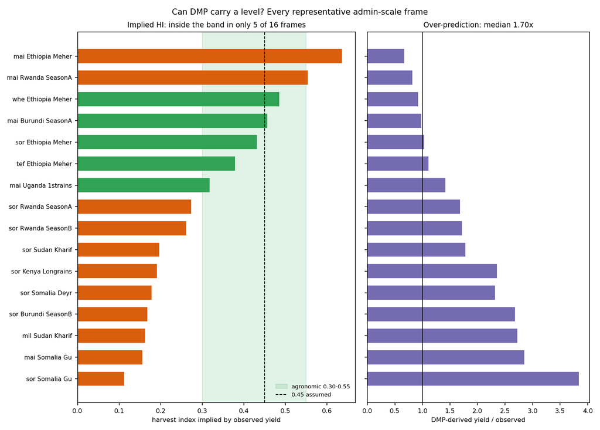

Figure 25. The harvest index implied by observed yields, across every representative admin-scale frame. Inside the green band the biomass is consistent with the harvest; outside it, no choice of harvest index rescues the level.

**The answer is no.** The implied harvest index lands inside the agronomic band in only **5 of 16** frames; the median is **0.267**, well below the 0.30 floor, and DMP-derived yield sits at a median **1.70×** of observed. Somalia sorghum Gu is 3.8×, Somalia maize Gu 2.9×, Sudan millet 2.7×. An implied HI of 0.11 is not a harvest index; it is the model saying the biomass it measured did not become grain at anything like the assumed rate.

> **This supersedes two earlier statements in this project, in opposite directions, and the history matters because both were argued from too little data.**

> The pipeline long carried *“DMP cannot see ASAL crop failure (implied HI 0.02)”*. That figure came from targeted ASAL drought crop-cutting campaigns — Embu, Kitui, Kwale, Machakos and Makueni in the 2021 and 2022 short rains, observed means of 0.23 and 0.06 t/ha. A sample selected toward poorly performing areas cannot test level skill, because any biomass product over-predicts against a harvest that did not happen. That evidence was inadmissible.

> Excluding it left three representative frames, on which DMP looked close to unbiased — and this report briefly said so. **Three frames was also too little.** Widened to sixteen, the original conclusion is vindicated on evidence that actually supports it: DMP runs high, and its implied harvest index is mostly outside the agronomic range.

**Rank skill is a separate question and the answer there is different.** Across these sixteen mixed frames DMP out-ranks CPI in only **7 of 16**, which is what the control set already predicted: DMP adds nothing where the water balance works. Its value is concentrated on the eight products where CPI ranks *backwards* — 3 wins, 0 losses, median Δρ +0.337 (§7.4). That is why DMP ships on those eight as a **ranking covariate**, exposed as kg DM/ha and never converted to a yield.

# 8. Departures from the Inception Report, and why

Each departure states what the report proposed, what was built, and the peer-reviewed basis.

## 8.1 Crop typing: Tier 1 was built stronger than proposed, Tier 3 was not attempted

*Report:* a three-tier strategy — Tier 1 a MapSPAM area-fraction prior over a cropland mask; Tier 2 label acquisition; Tier 3 a retrained S1/S2 phenometric classifier, adopted only if it beat Tier 1 on zone-level anomaly skill against FEWS NET IPC.

*Built:* Tier 1, but as a four-lineage sixteen-source-year cropland vote with suitability reweighting, satellite crop evidence and calibration to sub-national statistics — reproducing reported area to 92–99 %. **Tier 2 produced no usable labels, so Tier 3 is correctly not attempted**: the report’s own gate makes Tier 3 conditional on Tier 2.

*Basis:* Van Tricht et al. 2023 (WorldCereal) confirms no global millet or teff class exists, which is why a SPAM-prior mask is the only route to those crops; Eisfelder et al. 2024 is the S1+S2 classifier the report’s Tier 3 would have been, and needs labels the region does not have.

## 8.2 WRSI computed inside Earth Engine, not GeoWRSI

*Report:* the FEWS GeoWRSI convention. *Built:* the same algorithm (Verdin & Klaver 2002; Senay & Verdin 2003) reimplemented as a dekadal bucket in Earth Engine.

*Justification:* GeoWRSI is a desktop tool over pre-gridded inputs; running the identical recursion in Earth Engine lets the balance use **per-pixel planting dates** and **per-pixel rooting-depth WHC** from SoilGrids (Poggio et al. 2021; Saxton & Rawls 2006) at 250 m, which the desktop route cannot. The algorithm is unchanged; only where it runs, and at what resolution, has changed.

## 8.3 Cue-fusion green-up onset alongside the rainfall rule

*Report:* rainfall-threshold onset. *Built:* both, chosen per product.

*Justification:* the rainfall rule cannot fire where a season is not rain-triggered — Sudan’s November-sown irrigated wheat produced **zero valid pixels** on the 25/20 mm rule. Conversely, green-up fusion fails under persistent equatorial-highland cloud: Rwanda and Burundi Season A returned ~64 planting pixels against 3,365 crop pixels until they were routed to the rainfall rule. Neither detector is sufficient alone, and the failure modes are complementary — the optical/SAR fusion literature (Eisfelder et al. 2024) is explicit that SAR is the cloud-proof cue.

## 8.4 Multiplicative CPI rather than an additive index

*Justification:* FAO-33 (Doorenbos & Kassam 1979) combines stage water-deficit effects multiplicatively, and the same logic applies across stress types: a crop that has already failed for water cannot be further damaged proportionally by heat. An additive index would let a good heat score compensate a fatal water deficit.

## 8.5 `S_veg` is a down-weighted confirmation, not a driver

*Justification:* tested and rejected as a driver. DMP as `S_veg` gave no rank gain in any season (Ethiopia admin-2, n = 39, ρ ≈ 0 for both arms). Vegetation indices are diagnostic mid-season (Funk & Budde 2009; Rembold et al. 2013) and confirm what the balance already implies rather than adding independent information.

## 8.6 Ethiopia Meher maize keeps the operative calendar window

*Justification:* decided by A/B test, not assertion. The operative window beats GEOGLAM CM4EW by Δρ **+0.355 [+0.163, +0.564]** and the Inception Report window by **+0.463 [+0.229, +0.710]** (paired bootstrap, Efron & Tibshirani 1993) — the first A/B in the project whose intervals exclude zero. Coverage declines monotonically with the alternatives.

## 8.7 Sorghum calendars follow Inception Report Table 2.0

Not a departure but a deliberate alignment, recorded because GEOGLAM CM4EW ships a sorghum-*specific* calendar that disagrees with the report for 6 of the 9 products it covers, by up to 3 dekads. The CM4EW values are retained in parallel `cm4ew_*` columns for partner validation.

## 8.8 Irrigation is flagged, not corrected

*Departure:* the report assumes a rainfed balance throughout. *Built:* the same rainfed balance, plus an explicit per-product exposure grade (§7.3), because pretending the issue does not exist would misreport the Gezira as a crop failure.

## 8.9 Crop-type mask replaces WorldCereal as the stratum — for every crop except maize

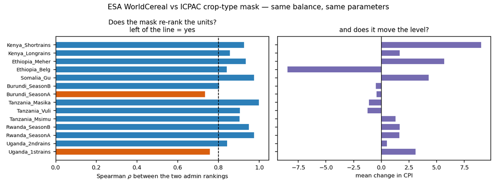

Figure 23. WorldCereal vs ICPAC crop-type mask for maize — same balance, same parameters, same Ym. Only the stratum differs.

Over 14 comparable products the level barely moves (mean CPI **+1.22**) and the ranking mostly holds (median ρ **0.905**), but **2 products re-rank** (Uganda 1st rains ρ 0.758, Burundi Season A ρ 0.734). Re-fitting Ym on the new footprint moves the ceilings by a median **−6.7 %** yet does **not** improve skill: held-out MAE improves in only 2 of 7 and r falls in 5 of 7.

**Conclusion: do not switch wholesale.** The mask is better at what it was built for — area — but that has not translated into better condition or yield. Switch per product, on evidence.

# 9. Known limitations

# 10. Recommendations, in order of value

1. **Split the crop masks by technology** using MapSPAM `_I`/`_R`, and run irrigated and rainfed products separately. This is the single highest-value fix: it makes 9 exposed products interpretable and unblocks an honest Ym re-fit.
2. **Add DMP as a ranking covariate** on the 8 anti-correlated products (§7.4) — evidence supports it there and nowhere else.
3. **Re-fit Ym on rainfed area only** once the split exists. Sudan sorghum’s r = −0.33 is the test: it should turn positive.
4. **Resolve Kenya short-rains season attribution** before that product is used for targeting.
5. **Obtain a teff Ky** from Ethiopian trial data; sensitivity-test Ky_flo over 0.4–0.8 meanwhile.
6. **Refresh the irrigation layer** against a post-2020 source.
7. **Switch maize to the crop-type mask per product, not wholesale**, re-fitting Ym each time.

# 11. References

All references below are reproduced from the project’s maintained bibliography, `REFERENCES.md`, which carries the full annotated list.

**Verification status.** All **42 DOIs in the bibliography resolve, and each resolved record’s title matches the citation** — checked on 26 September 2026 by DOI content negotiation against Crossref/DataCite (`verify_dois.py`, results in `doi_verification.csv`), not by eye. Two entries that had been anonymous placeholders were completed with their authors and DOIs in the process.

What remains unverified is not the DOIs but the 11 entries that have none — books, monographs and agency reports such as FAO (1978), Jones & Kiniry (1986) and Jaetzold et al. (2006–2012). One, De Groote et al. (2005, eJADE), could not be confirmed by Crossref search and **should be checked against a library before citing**. The MapSPAM release identifier should likewise be cited from the exact Dataverse record used.

## Start-of-season / planting-date from SAR–optical fusion

- Van Tricht, K. et al. (2023). *WorldCereal: a dynamic open-source system for global-scale, seasonal, reproducible crop and irrigation mapping.* Earth System Science Data 15, 5491–5515. https://doi.org/10.5194/essd-15-5491-2023 — the 10 m global cropland/maize/cereal system; confirms no millet/teff class (motivates crop-specific masking).
- Eisfelder, C. et al. (2024). *Cropland and Crop Type Classification with Sentinel-1 and Sentinel-2 Time Series Using GEE for Agricultural Monitoring in Ethiopia.* Remote Sensing 16(5):866. https://doi.org/10.3390/rs16050866 — S1+S2 time-series, red-edge indices, 10 m, three Ethiopian regions (methodological basis for feature stack).
- Shojaeezadeh, S.A., Elnashar, A. & Weber, T.K.D. (2025). *A novel fusion of Sentinel-1 and Sentinel-2 with climate data for crop phenology estimation using machine learning.* Science of Remote Sensing 11:100227. https://doi.org/10.1016/j.srs.2025.100227
- 2025. *Time-series analysis of Sentinel-1 SAR to retrieve annual rice area and long-term dynamics of start of season.* Scientific Reports. https://doi.org/10.1038/s41598-025-91655-z — SAR-only SOS retrieval; supports SAR as the cloud-proof onset cue.
- 2025. *Parcel-scale crop planting structure extraction combining time-series Sentinel-1 and Sentinel-2 via a semantic edge-aware multi-task network.* Int. J. Digital Earth. https://doi.org/10.1080/17538947.2025.2497487
- 2026. *Evaluating the impact of PlanetScope and Sentinel-2 data fusion on maize phenometrics retrieval.* GIScience & Remote Sensing. https://doi.org/10.1080/15481603.2026.2637207 — supports higher-res fusion for smallholder maize phenometrics.
- Vrieling, A. et al. (2019). *Exploiting time series of Sentinel-1 and Sentinel-2 to detect meadow phenology.* Remote Sensing 11(5):542. https://doi.org/10.3390/rs11050542

## WRSI / crop water balance & rainfall onset

- Verdin, J. & Klaver, R. (2002). *Grid-cell-based crop water accounting for the famine early warning system.* Hydrological Processes 16, 1617–1630. https://doi.org/10.1002/hyp.1025
- Senay, G.B. & Verdin, J. (2003). *Characterization of yield reduction in Ethiopia using a GIS-based crop water balance model.* Canadian J. Remote Sensing 29(6), 687–692. https://doi.org/10.5589/m03-039 — WRSI onset rule (25/20 mm) and cycle water balance.
- Funk, C. et al. (2015). *The climate hazards infrared precipitation with stations (CHIRPS).* Scientific Data 2:150066. https://doi.org/10.1038/sdata.2015.66
- Allen, R.G., Pereira, L.S., Raes, D., Smith, M. (1998). *Crop evapotranspiration — Guidelines for computing crop water requirements.* FAO Irrigation & Drainage Paper 56 (FAO-56); crop coefficients & stage lengths (Kc curve). https://www.fao.org/3/x0490e/x0490e00.htm
- Hargreaves, G.H. & Samani, Z.A. (1985). *Reference crop evapotranspiration from temperature.* Applied Engineering in Agriculture 1(2), 96–99. https://doi.org/10.13031/2013.26773 — the temperature-only ET0 used here (ERA5-Land inputs).
- Muñoz-Sabater, J. et al. (2021). *ERA5-Land.* Earth System Science Data 13, 4349–4383. https://doi.org/10.5194/essd-13-4349-2021 — Tmin/Tmax source for ET0.
- Saxton, K.E. & Rawls, W.J. (2006). *Soil water characteristic estimates by texture and organic matter for hydrologic solutions.* Soil Sci. Soc. Am. J. 70(5), 1569–1578. https://doi.org/10.2136/sssaj2005.0117 — field capacity (θ₃₃) & wilting point (θ₁₅₀₀) pedotransfer for WHC.
- Poggio, L. et al. (2021). *SoilGrids 2.0: producing soil information for the globe with quantified spatial uncertainty.* SOIL 7, 217–240. https://doi.org/10.5194/soil-7-217-2021 — sand/clay/SOC texture inputs to the WHC pedotransfer. (Legacy: OpenLandMap 33 kPa, https://doi.org/10.5281/zenodo.2784001.)
- Rembold, F. et al. (2019). *ASAP: a new global early warning system to detect anomaly hot spots of agricultural production.* Agricultural Systems 168, 247–257. https://doi.org/10.1016/j.agsy.2018.07.002 — ASAP % -of-crop-area rule and the FPAR anomaly (zFPAR) option.
- Sivakumar, M.V.K. (1988). *Predicting rainy season potential from the onset of rains… West Africa.* Agric. & Forest Meteorology 42(4), 295–305. https://doi.org/10.1016/0168-1923(88)90039-1 — the accumulation + no-dry-spell onset criterion (“5+7” false-start gate).
- Stern, R.D., Dennett, M.D. & Dale, I.C. (1982). *Analysing daily rainfall measurements to give agronomically useful results.* Experimental Agriculture 18(3), 223–236. https://doi.org/10.1017/S001447970001379X — onset & dry-spell risk from daily rainfall.

## Excess rain / waterlogging (wet-side risk)

- Zaidi, P.H. et al. (2004). *Tolerance to excess moisture in maize: susceptible crop stages…* Field Crops Research 90(2–3), 189–202. https://doi.org/10.1016/j.fcr.2004.03.002 — early-vegetative the most waterlogging-susceptible stage (basis for the excess stage-weighting order).
- Ren, B. et al. (2014). *Effects of waterlogging on the yield and growth of summer maize under field conditions.* Canadian J. Plant Science 94(1), 23–31. https://doi.org/10.4141/cjps2013-175
- Kaur, G. et al. (2020). *Impacts and management strategies for crop production in waterlogged or flooded soils: a review.* Agronomy Journal 112(3), 1475–1501. https://doi.org/10.1002/agj2.20093

## FPAR / phenology inputs

- Myneni, R. et al. MODIS MCD15A3H FPAR/LAI (C6.1). NASA LP DAAC. https://doi.org/10.5067/MODIS/MCD15A3H.061
- Copernicus Global Land Service — FPAR 300 m. https://land.copernicus.eu/global

## Regional monitoring, calendars, statistics (calibration/validation)

- Becker-Reshef, I. et al. (2020). *The GEOGLAM Crop Monitor for Early Warning.* Remote Sensing of Environment 237:111553. https://doi.org/10.1016/j.rse.2019.111553 | https://cropmonitor.org
- Nakalembe, C., Becker-Reshef, I., Bonifacio, R. et al. (2021). *A review of satellite-based global agricultural monitoring systems available for Africa.* Global Food Security 29:100543. https://doi.org/10.1016/j.gfs.2021.100543
- Lee, D. et al. (2025). *HarvestStat Africa — Harmonized Subnational Crop Statistics for Sub-Saharan Africa.* Scientific Data. https://doi.org/10.1038/s41597-025-05001-z
- FEWS NET crop calendars & data portal. https://fews.net/data
- FAO GIEWS Country Briefs / crop calendars. https://www.fao.org/giews/

## Reference / ground-truth labels

- Ethiopian Crop Type 2020 (EthCT2020). Data in Brief (2024). https://www.sciencedirect.com/science/article/pii/S2352340924003962 Dataset: Mendeley Data https://doi.org/10.17632/mfpvmk8cnm.1

## Data-access API documentation

- Google Earth Engine — https://developers.google.com/earth-engine
- Copernicus Data Space Ecosystem APIs (openEO, Sentinel Hub, STAC/OData) — https://dataspace.copernicus.eu/analyse/apis
- NASA AppEEARS API — https://appeears.earthdatacloud.nasa.gov/api
- ASF HyP3 (Sentinel-1 RTC on demand) — https://hyp3-docs.asf.alaska.edu
- USGS FEWS NET / GeoWRSI software — https://earlywarning.usgs.gov/fews/software-tools

**Verification status (checked 26 September 2026, `verify_dois.py`).** All **42 DOIs in this file resolve, and each resolved record’s title matches the citation here** — checked by DOI content negotiation against Crossref/DataCite, not by eye. Re-run with `python verify_dois.py`; results in `doi_verification.csv`.

Two entries that were previously anonymous placeholders (“(2025) *A novel fusion…*”, “(2021) *A review…*”) have been completed with their authors and DOIs, and DOIs were added for Running et al. (2004) and Ritchie & NeSmith (1991).

**What is still unverified**, and it is not the DOIs: 11 entries are books, monographs, agency reports and one 2005 journal article with no DOI to check — Stone (1974), Efron & Tibshirani (1993), FAO (1978), Jones & Kiniry (1986), Kiniry & Bonhomme (1991), Jaetzold et al. (2006–2012), Hassan (1998), De Groote et al. (2005) and similar. These were confirmed against a Crossref search where a record exists; De Groote et al. (2005, eJADE) returned only a different 2023 paper by the same author, so **check that one against a library before citing it**. Live URLs resolve except three that return 403 to automated requests (ScienceDirect, mapspam.info) and two agency APIs — all reachable in a browser.

## Productivity / biomass-based yield (DMP, added 2026-09)

- Monteith, J.L. (1972). *Solar radiation and productivity in tropical ecosystems.* Journal of Applied Ecology 9(3), 747–766. https://doi.org/10.2307/2401901 — light-use-efficiency basis of DMP.
- Running, S.W., Nemani, R.R., Heinsch, F.A. et al. (2004). *A continuous satellite-derived measure of global terrestrial primary production.* BioScience 54(6), 547–560. https://doi.org/10.1641/0006-3568(2004)054[0547:ACSMOG]2.0.CO;2 — MOD17 GPP/NPP algorithm (the MODIS stand-in for CGLS DMP).
- Zhao, M. et al. (2005). *Improvements of the MODIS terrestrial gross and net primary production global data set.* Remote Sensing of Environment 95(2), 164–176. https://doi.org/10.1016/j.rse.2004.12.011
- Hay, R.K.M. (1995). *Harvest index: a review of its use in plant breeding and crop physiology.* Annals of Applied Biology 126(1), 197–216. https://doi.org/10.1111/j.1744-7348.1995.tb05015.x — the 0.30–0.55 agronomic range against which the implied HI is read as a mask diagnostic.

## Thermal time / phenology (added 2026-09)

- McMaster, G.S. & Wilhelm, W.W. (1997). *Growing degree-days: one equation, two interpretations.* Agricultural and Forest Meteorology 87(4), 291–300. https://doi.org/10.1016/S0168-1923(97)00027-0

## Yield ceiling / yield gap (added 2026-09)

- van Ittersum, M.K. et al. (2013). *Yield gap analysis with local to global relevance — a review.* Field Crops Research 143, 4–17. https://doi.org/10.1016/j.fcr.2012.09.009
- Lobell, D.B., Cassman, K.G. & Field, C.B. (2009). *Crop yield gaps: their importance, magnitudes, and causes.* Annual Review of Environment and Resources 34, 179–204. https://doi.org/10.1146/annurev.environ.041008.093740

## Validation statistics (added 2026-09)

- Stone, M. (1974). *Cross-validatory choice and assessment of statistical predictions.* JRSS B 36(2), 111–147. — leave-one-out CV.
- Efron, B. & Tibshirani, R.J. (1993). *An Introduction to the Bootstrap.* Chapman & Hall. — paired bootstrap CI on the arm difference.

## Agro-ecological zoning, growing period & maize maturity classes (added 2026-09)

**Agro-ecological zoning & growing period** - FAO (1978). *Report on the Agro-ecological Zones Project, Vol. 1: Methodology and Results for Africa.* World Soil Resources Report 48, FAO, Rome. — origin of the Length of Growing Period (LGP) concept and the P/PET ≥ 0.5 moisture-adequacy criterion used in `src/agroecology.lgp_dekads`. - Fischer, G., van Velthuizen, H., Nachtergaele, F. et al. (2021). *Global Agro-Ecological Zones (GAEZ v4) — Model Documentation.* FAO & IIASA. https://doi.org/10.4060/cb4744en — the current operational LGP/AEZ product against which a pipeline LGP should be benchmarked.

**Maize thermal time & phenology modelling** - Jones, C.A. & Kiniry, J.R. (1986). *CERES-Maize: A Simulation Model of Maize Growth and Development.* Texas A&M University Press. — thermal-time accumulation and stage partitioning for maize. - Kiniry, J.R. & Bonhomme, R. (1991). *Predicting maize phenology.* In: Hodges, T. (ed.) *Predicting Crop Phenology*, CRC Press, 115–131. — GDD-to-stage targets and cultivar maturity classes.

**Kenyan maize varieties, maturity classes & agro-ecological matching** - Jaetzold, R., Schmidt, H., Hornetz, B. & Shisanya, C. (2006–2012). *Farm Management Handbook of Kenya, Vol. II: Natural Conditions and Farm Management Information* (2nd edn). Ministry of Agriculture, Kenya / GTZ. — the standard Kenyan agro-ecological zone reference, including recommended maize maturity class and variety by zone; basis for `config/maize_variety_gdd.csv`. - Hassan, R.M. (ed.) (1998). *Maize Technology Development and Transfer: A GIS Application for Research Planning in Kenya.* CAB International, Wallingford. — GIS characterisation of Kenyan maize production systems and the altitude/maturity convention of the H5/H6 hybrid series. - De Groote, H., Owuor, G., Doss, C., Ouma, J., Muhammad, L. & Danda, K. (2005). *The maize green revolution in Kenya revisited.* electronic Journal of Agricultural and Development Economics (eJADE) 2(1), 32–49. — adoption of hybrid maturity classes by agro-ecological zone.

**Non-parametric testing** - Mann, H.B. & Whitney, D.R. (1947). *On a test of whether one of two random variables is stochastically larger than the other.* Annals of Mathematical Statistics 18(1), 50–60. https://doi.org/10.1214/aoms/1177730491 — used in §5.2 to test whether model error is larger where the thermal requirement exceeds the moisture window.

## Yield response to water, crop area maps, boundaries (added 2026-09-26)

- Doorenbos, J. & Kassam, A.H. (1979). *Yield response to water.* FAO Irrigation & Drainage Paper 33, FAO, Rome. https://www.fao.org/3/x0490e/x0490e00.htm (companion to FAO-56) — the stage yield-response factors Ky (vegetative / flowering / grain-fill) that weight `S_water`, and the multiplicative combination of stage stresses. **The single most consequential parameter set in this pipeline.**
- International Food Policy Research Institute (IFPRI). *Global Spatially-Disaggregated Crop Production Statistics Data (MapSPAM), version 2020.* Harvard Dataverse. https://mapspam.info — crop area shares by technology (irrigated `_I`, rainfed `_R`, all `_A`), the prior for the crop-type mask’s dasymetric allocation and the basis of the irrigation-exposure grading. *Cite the exact version DOI from the Dataverse record used; the release identifier is not reproduced here.*
- GADM. *Database of Global Administrative Areas, version 4.1.* https://gadm.org — admin-1/2/3 boundaries for the zonal reductions.
- FAO. *GAUL: Global Administrative Unit Layers.* https://data.apps.fao.org/catalog/ — legacy admin boundaries, retained only where GADM lacks a layer.

## Prognostic vs diagnostic phenology — why forecasting needs the thermal clock (added 2026-09)

- Ritchie, J.T. & NeSmith, D.S. (1991). *Temperature and crop development.* In: Modeling Plant and Soil Systems, Agronomy Monograph 31, ASA-CSSA-SSSA, 5–29. https://doi.org/10.2134/agronmonogr31.c2
- Holzworth, D.P. et al. (2014). *APSIM - evolution towards a new generation of agricultural systems simulation.* Environmental Modelling & Software 62, 327-350. https://doi.org/10.1016/j.envsoft.2014.07.009
- Basso, B. & Liu, L. (2019). *Seasonal crop yield forecast: Methods, applications, and accuracies.* Advances in Agronomy 154, 201-255. https://doi.org/10.1016/bs.agron.2018.11.002
- Funk, C. & Budde, M.E. (2009). *Phenologically-tuned MODIS NDVI-based production anomaly estimates for Zimbabwe.* Remote Sensing of Environment 113(1), 115-125. https://doi.org/10.1016/j.rse.2008.08.015 - index-based estimation is mid-season onward.
- Becker-Reshef, I. et al. (2010). *A generalized regression-based model for forecasting winter wheat yields…* Remote Sensing of Environment 114(6), 1312-1323. https://doi.org/10.1016/j.rse.2010.01.010
- Rembold, F. et al. (2013). *Using low resolution satellite imagery for yield prediction and yield anomaly detection.* Remote Sensing 5(4), 1704-1733. https://doi.org/10.3390/rs5041704
- Jones, P.G. & Thornton, P.K. (2003). *The potential impacts of climate change on maize production in Africa and Latin America in 2055.* Global Environmental Change 13(1), 51-59. https://doi.org/10.1016/S0959-3780(02)00090-0 - LGP as agro-climatic screening axis.

*Generated 2026-09-26 by `report/build_report.py` from 40 shipped products. Companion files: `report/product_master_table.csv` (every product, every headline metric), `crop_products/<crop>/METHODOLOGY.md` (per-crop dossiers), `crop_pipeline/docs/IRRIGATED_WATER_BALANCE.md`, `CPI_METHODOLOGY.md`, `ALL_COUNTRIES_2024.md`.*

# Appendix A — every product, every headline metric

Area-weighted means across admin-1 units. `r` is the yield-pattern skill of that product’s fitted ceiling; blank means no ceiling could be fitted.

| crop | country | season | units | plant_dk | CPI | t/ha | fail% | def_mm | FCCI | irrigation | Ym | r |
| --- | --- | --- | --- | --- | --- | --- | --- | --- | --- | --- | --- | --- |
| maize | Burundi | SeasonA | 17 | 27.00 | 86.50 | 5.20 | 0.20 | 0.00 | 68.80 | — | 1.88 | 0.28 |
| maize | Burundi | SeasonB | 17 | 5.80 | 79.00 | 4.80 | 0.20 | 0.00 | 49.80 | — | 1.88 | 0.28 |
| maize | Ethiopia | Belg | 11 | 7.10 | 67.30 | 3.50 | 5.50 | 31.90 | 51.00 | locally biased | 4.14 | 0.64 |
| maize | Ethiopia | Meher | 11 | 11.20 | 82.10 | 4.90 | — | — | 71.00 | locally biased | 4.14 | 0.64 |
| maize | Kenya | Longrains | 44 | 9.20 | 83.90 | 5.00 | — | — | 86.30 | — | 2.34 | 0.57 |
| maize | Kenya | Shortrains | 16 | 27.20 | — | — | — | — | — | — | 2.34 | 0.57 |
| maize | Rwanda | SeasonA | 5 | 27.00 | 81.90 | 4.90 | 0.70 | 0.00 | 57.10 | — | 2.61 | -0.07 |
| maize | Rwanda | SeasonB | 5 | 6.80 | 79.40 | 4.80 | 0.70 | 0.30 | 51.00 | — | 2.61 | -0.07 |
| maize | Somalia | Deyr | 6 | 30.50 | 0.00 | 0.00 | 90.10 | 203.30 | 40.40 | materially biased | — | — |
| maize | Somalia | Gu | 9 | 9.70 | 37.50 | 2.20 | 4.00 | 69.90 | 64.00 | materially biased | — | — |
| maize | Tanzania | Masika | 20 | 6.40 | 73.90 | 4.30 | 3.10 | 23.50 | 55.40 | — | — | — |
| maize | Tanzania | Msimu | 31 | 33.90 | 80.20 | 4.80 | 0.10 | 2.70 | 56.00 | — | — | — |
| maize | Tanzania | Vuli | 30 | 30.80 | 81.80 | 4.90 | 0.10 | 3.90 | 60.30 | — | — | — |
| maize | Uganda | 1strains | 55 | 7.40 | 68.40 | 4.10 | 0.10 | 20.80 | 53.60 | — | 2.34 | -0.14 |
| maize | Uganda | 2ndrains | 55 | 23.00 | 83.50 | 5.00 | 0.10 | 2.50 | 62.90 | — | 2.34 | -0.14 |
| millet | Eritrea | Kremti | 4 | 17.70 | 75.80 | 1.60 | 0.10 | 51.90 | 87.00 | — | — | — |
| millet | Sudan | Kharif | 15 | 17.60 | 63.80 | 1.30 | 0.50 | 109.30 | 33.70 | materially biased | 0.63 | 0.24 |
| sorghum | Burundi | SeasonA | 7 | 27.00 | 72.00 | 2.20 | 1.70 | 0.00 | 58.10 | — | 0.55 | -0.09 |
| sorghum | Burundi | SeasonB | 7 | 5.30 | 77.40 | 2.40 | 1.70 | 0.50 | 86.40 | — | 0.55 | -0.09 |
| sorghum | Eritrea | Kremti | 5 | 15.40 | 91.80 | 2.70 | 1.00 | 20.30 | 85.00 | — | — | — |
| sorghum | Ethiopia | Belg | 9 | 7.10 | 70.10 | 2.10 | 2.00 | 43.40 | 47.80 | — | 2.60 | 0.22 |
| sorghum | Ethiopia | Meher | 9 | 15.00 | 87.40 | 2.60 | 0.10 | 5.80 | 83.30 | — | 2.60 | 0.22 |
| sorghum | Kenya | Longrains | 20 | 6.90 | 76.60 | 2.30 | 0.20 | 36.70 | 65.40 | — | 1.42 | 0.54 |
| sorghum | Kenya | Shortrains | 20 | 29.60 | 81.40 | 1.60 | 0.10 | 20.10 | 51.80 | — | 1.42 | 0.54 |
| sorghum | Rwanda | SeasonA | 5 | 27.00 | 76.60 | 2.30 | 0.70 | 0.00 | 64.80 | — | 1.34 | 0.43 |
| sorghum | Rwanda | SeasonB | 5 | 6.40 | 76.60 | 2.30 | 0.70 | 3.90 | 90.20 | — | 1.34 | 0.43 |
| sorghum | Somalia | Deyr | 8 | 30.40 | 16.50 | 0.30 | 50.90 | 177.90 | 56.60 | materially biased | 0.41 | 0.26 |
| sorghum | Somalia | Gu | 8 | 9.30 | 53.30 | 1.60 | 2.60 | 61.70 | 71.00 | materially biased | 0.41 | 0.26 |
| sorghum | South Sudan | 2nd | 10 | 20.00 | 80.00 | 1.60 | 0.30 | 18.40 | 80.00 | — | — | — |
| sorghum | South Sudan | Main | 10 | 15.20 | 76.10 | 2.30 | 0.20 | 53.10 | 65.50 | — | — | — |
| sorghum | Sudan | Kharif | 18 | 18.20 | 52.00 | 1.50 | 2.30 | 114.40 | 39.80 | materially biased | 0.83 | -0.33 |
| sorghum | Tanzania | Masika | 5 | 6.00 | 92.90 | 2.70 | 0.00 | 8.10 | 57.00 | — | — | — |
| sorghum | Tanzania | Msimu | 17 | 33.00 | 80.30 | 2.40 | 0.00 | 26.60 | 26.30 | — | — | — |
| sorghum | Uganda | 1strains | 24 | 7.10 | 74.50 | 2.20 | 0.70 | 20.40 | 78.60 | — | 1.30 | -0.02 |
| sorghum | Uganda | 2ndrains | 25 | 26.70 | 82.10 | 1.60 | 0.50 | 2.30 | 69.90 | — | 1.30 | -0.02 |
| teff | Ethiopia | Meher | 6 | 18.10 | 84.50 | 1.60 | 0.30 | 8.70 | 83.80 | — | 1.77 | 0.33 |
| wheat | Ethiopia | Meher | 5 | 17.20 | 85.10 | 3.40 | 0.10 | 7.90 | 83.20 | — | 2.69 | 0.15 |
| wheat | Kenya | Longrains | 16 | 11.10 | 83.60 | 3.30 | 0.00 | 0.70 | 67.80 | — | 3.11 | 0.07 |
| wheat | Sudan | Shitwi | 6 | 31.00 | 0.00 | 0.00 | 100.00 | 461.30 | 26.90 | INVALID as rainfed | — | — |
| wheat | Tanzania | Msimu | 5 | 2.40 | 88.40 | 3.50 | 0.00 | 0.20 | 58.90 | — | — | — |